# Data Visualization using Matplotlib

**Matplotlib is a Python plotting library which produces publication quality figures in a variety of hardcopy formats and interactive environments across multiple platforms.**

**`Matplotlib tries to make easy things easy and hard things possible.` You can generate plots, histograms, power spectra, bar charts, errorcharts, scatterplots, etc., with just a few lines of code.**

The matplotlib library contains several modules. For example, the `matplotlib.table` module includes tools for constructing tables, the `matplotlib.text` module for including text in a figure, and the `matplotlib.colorbar` module allows you to visualize a set of scalar values in color. The `matplotlib.pyplot` module is designed to create colorful plots.

# Table of Contents

- Installation
- Getting Started With Pyplot
  - World population graph
  - Adding labels and custom line color
  - Legends, Titles, and Labels
  - Multiple lines and line styling
  - Configuring the graph
- The pie chart
- The doughnut chart
- The heatmap
- The bar charts
- The Histogram
- Scatter Plots
- Stack Plots
- 3D graphs
- 3D Scatter Plot
- 3D Bar Chart
- Plotting Images

# Installation

Windows, Linux and macOS distributions have matplotlib and most of its dependencies as wheel packages. Run the following command to install matplotlib package :

`pip install matplotlib`

**Importing matplotlib**

`from matplotlib import pyplot as plt`

or

`import matplotlib.pyplot as plt`

## Import Essential Packages

```python
import numpy as np
import pandas as pd
import matplotlib
import matplotlib.pyplot as plt
import matplotlib.image as mpimg
%matplotlib inline

import os
os.listdir('./data')
```

```
['Iris.csv', 'test_image_png_1051.png']
```

## Check Packages version

```python
# Check matplotlib version
print(matplotlib.__version__)
print(pd.__version__)
print(np.__version__)
```

```
3.0.3
0.23.4
1.16.3
```

# Getting Started With Pyplot

Pyplot is a Matplotlib module that provides simple functions for adding plot elements, such as lines, images, text, etc. to the axes in the current figure.

Let's begin with a simple graph that uses fundamental Matplotlib code.

`fig, ax = plt.subplots() # this creates a figure paired with axes`

**Matplotlib** employs a hierarchical structure, with a `figure` object on top. A figure is a container that consists of many different elements, including axes. A figure can change the graph size, manage titles, and figure legends among other things. An `axis` is an object that takes data and visualizes it on the plot one figure can have several axes that correspond to different subgraphs.

Now let's create our first graph:

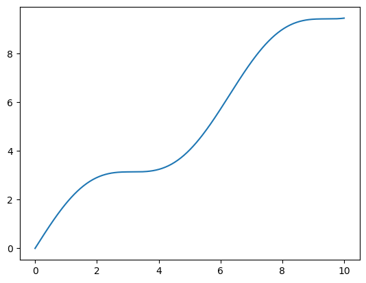

```python
import matplotlib.pyplot as plt
import numpy as np
fig, ax = plt.subplots()
# x data
x = np.linspace(0, 10, 300)
# y data
y = np.sin(x) + x
# creates the plot
ax.plot(x, y)
# this will show your plot in case your environment is not interactive
plt.show()
```

There is also another way to create a figure in `matplotlib`:

`plt.figure()`

This code looks a bit simpler but that's the only positive side. A lot of times, you need to draw several plots in succession. Matplotlib employs an "active figure" concept. Suppose, we need to implement `plt.figure(num)` in our program. In this case, it creates a new figure, assigns it with a `num` number and makes it active. If we want to go back to one of the previous charts, we need to refer to the specific figure instead of creating a new one. To do so, we need to track its number — say, 7 — and activate the desired figure with the `plt.figure(7)` command.

Besides, the `plt.subplots()` function is crucial when you want to create a plot consisting of several parts.

## Plot settings

Now let's customize our plot and learn some of the basic settings.

The `figsize` argument sets the figure `length` and `width`:

`fig, ax = plt.subplots(figsize=(15,10))`

The `suptitle` method sets the figure's `title`.

`fig.suptitle('Our First plot', fontsize=40)`

We can also set line `color`, `style`, and `width`.To change the line appearance the `linestyles` is used. Additional width will make our line a bit thicker for a better visual appearance.

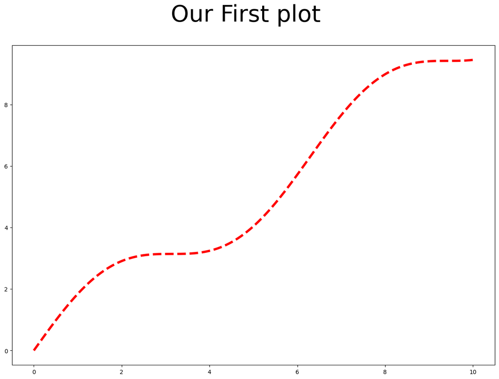

```python
color = 'r'
linestyle = 'dashed'
linewidth = 4
fig, ax = plt.subplots(figsize=(15,10))
fig.suptitle('Our First plot', fontsize=40)
ax.plot(x, y, c=color, linestyle=linestyle, linewidth=linewidth)
plt.show()
```

### Axes settings

Let's get a glance at some of the Axes class properties.To name our `x` and `y` axes. We can pass any keyword arguments:

```
ax.set_ylabel('function', fontsize = 30)
ax.set_xlabel('argument', fontsize = 30)
```

The Axes object has two child objects: `xaxis` and `yaxis`. Each of them has its own ticks with bound labels — in our case, the numbers under the axis line. We can subsequently iterate through them, changing their `size`:

```
for xtick in ax.xaxis.get_major_ticks():
    xtick.label.set_fontsize(18)

for ytick in ax.yaxis.get_major_ticks():
    ytick.label.set_fontsize(18)
```

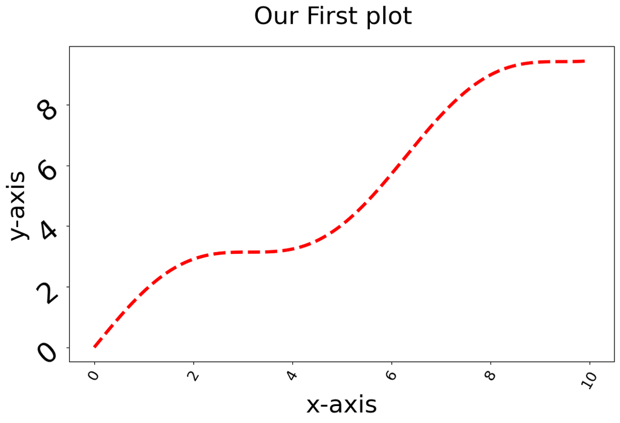

```python
fig, ax = plt.subplots(figsize=(12,7))
fig.suptitle('Our First plot', fontsize=30)
color = 'r'
linestyle = 'dashed'
linewidth = 4
ax.plot(x, y, c=color, linestyle=linestyle, linewidth=linewidth)
ax.set_ylabel('y-axis', fontsize = 30)
ax.set_xlabel('x-axis', fontsize = 30)
for xtick in ax.xaxis.get_major_ticks():
    xtick.label.set_fontsize(18)

for ytick in ax.yaxis.get_major_ticks():
    ytick.label.set_fontsize(34)
plt.xticks(rotation=60)
plt.yticks(rotation=40)
plt.show()
```

## 🎗️ Reminder

It is a good practice to close the figure windows when we don't need them it keeps the code clean and saves a lot of memory. To do this, we can use the `plt.close(fig)` command. Use the `plt.close()` command to close all open figure windows. If you need to delete a particular figure including associated axes with data, use `fig.clf()`. It deletes the figure content but leaves the figure window open.

### Multiple subplots

The `plt.subplots()` method is the best way to handle several subplots at once. Let's create a plot in three parts:

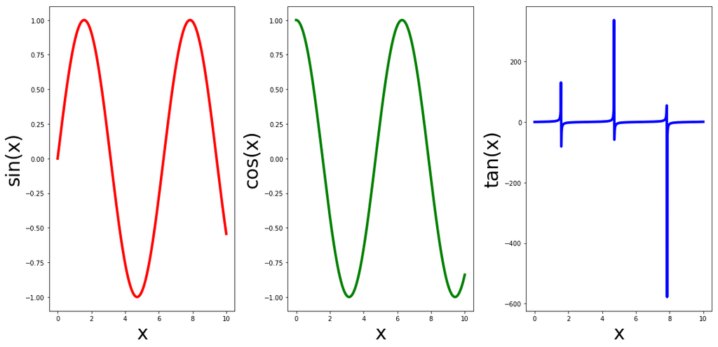

```python
import matplotlib.pyplot as plt
import numpy as np
fig, axes = plt.subplots(1, 3, figsize=(16,8))
ax1, ax2, ax3 = axes
x = np.linspace(0,10,500)
y1 = np.sin(x)
y2 = np.cos(x)
y3 = np.tan(x)

ax1.set_ylabel('sin(x)', fontsize=30)
ax1.set_xlabel('x', fontsize=30)
ax2.set_ylabel('cos(x)', fontsize=30)
ax2.set_xlabel('x', fontsize=30)
ax3.set_ylabel('tan(x)', fontsize=30)
ax3.set_xlabel('x', fontsize=30)
fig.tight_layout(pad=2)

ax1.plot(x, y1, c='r', linewidth=4)
ax2.plot(x, y2, c='g', linewidth=4)
ax3.plot(x, y3, c='b', linewidth=4)
plt.show()
```

## Some other example

### World population graph

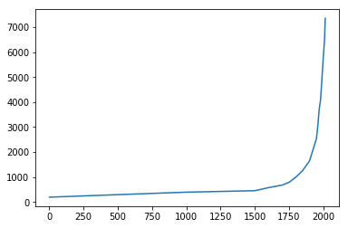

```python
import matplotlib.pyplot as plt
years=[1,1000,1500,1600,1700,1750,1800,1850,1900,1950,1955,1960,1965,1970,1980,1985,1990,
       1995,2000,2005,2010,2015]
pops=[200,400,458,580,682,791,1000,1262,1650,2525,2758,3018,3322,3682,
      4061,4440,4853,5310,5735,6127,6520,7349]
plt.plot(years,pops)
plt.show()
```

### Adding labels and custom line color

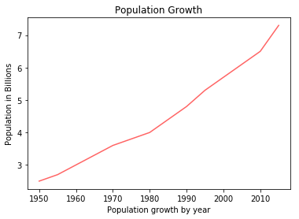

```python
years=[1950,1955,1960,1965,1970,1980,1985,1990,1995,2000,2005,2010,2015]
pops=[2.5,2.7,3.0,3.3,3.6,4.0,4.4,4.8,5.3,5.7,6.1,6.5,7.3]
plt.plot(years,pops,color=(255/255,100/255,100/255))
plt.ylabel("Population in Billions")
plt.xlabel("Population growth by year")
plt.title("Population Growth")
plt.show()
```

### Legends, Titles, and Labels

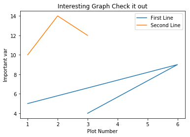

```python
x = [1,6,3]
y = [5,9,4]

x2 = [1,2,3]
y2 = [10,14,12]

plt.plot(x, y, label='First Line')
plt.plot(x2, y2, label='Second Line')
plt.xlabel('Plot Number')
plt.ylabel('Important var')
plt.title('Interesting Graph Check it out')
plt.legend()
plt.show()
```

### Multiple lines and line styling

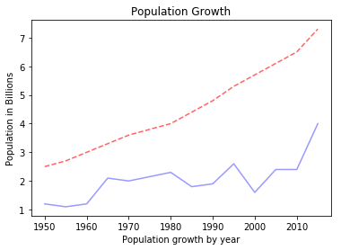

```python
years=[1950,1955,1960,1965,1970,1980,1985,1990,1995,2000,2005,2010,2015]
pops=[2.5,2.7,3.0,3.3,3.6,4.0,4.4,4.8,5.3,5.7,6.1,6.5,7.3]
death=[1.2,1.1,1.2,2.1,2.0,2.3,1.8,1.9,2.6,1.6,2.4,2.4,4.0]
plt.plot(years,pops,'--',color=(255/255,100/255,100/255))
plt.plot(years,death,color=(.6,.6,1))
plt.ylabel("Population in Billions")
plt.xlabel("Population growth by year")
plt.title("Population Growth")
plt.show()
```

### Configuring the graph

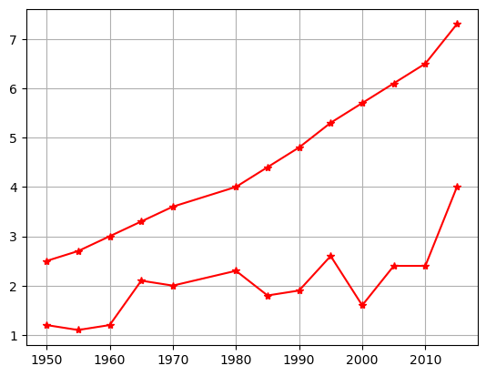

```python
years=[1950,1955,1960,1965,1970,1980,1985,1990,1995,2000,2005,2010,2015]
pops=[2.5,2.7,3.0,3.3,3.6,4.0,4.4,4.8,5.3,5.7,6.1,6.5,7.3]
death=[1.2,1.1,1.2,2.1,2.0,2.3,1.8,1.9,2.6,1.6,2.4,2.4,4.0]
lines=plt.plot(years,pops,years,death)
plt.grid(True)
plt.setp(lines,color='r',marker='*')
plt.show()
```

# The pie chart

A `pie chart` is a circular plot that shows how data items relate to one another. The `pie chart` total area is the data percentage. The area of `slices` (also called `wedges`) represents the percentage of data parts and shows the relation between them. `Pie charts` are good when we need to compare parts of a whole.

### Creating a pie chart

To create a pie chart using matplotlib, refer to the pie`() function`.

`plt.pie(data)`

where `data` is an array of data values that you want to plot.

There are many other optional parameters that can pass to `plt.pie()`. Some of them include:

- `explode` allows separating slices of a pie chart
- `labels` is a list of strings that sets the label of each corresponding slice
- `labeldistance` determines the radial distance at which pie labels are drawn (default is `1.1`)
- `color` colors slices
- `shadow` creates the shadow of a slice
- `startangle` lets you choose the starting angle of a plot
- `wedgeprops` lets you tune various slice parameters
- `radius` sets the radius of the circle(by default, it is `1`)

Let's create simple pie chart. Assume our data represents the result of a survey on a favorite programming language:

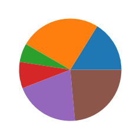

```python
import matplotlib.pyplot as plt
data=[33,52,12,17,42,48]
plt.pie(data)
plt.show()
```

### Labels

Adding labels to a pie chart is pretty straightforward just need to pass a list of strings with labels corresponding to the list of values:

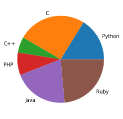

```python
data=[33,52,12,17,42,48]
labels=['Python','C','C++','PHP','Java','Ruby']
plt.pie(data,labels=labels)
plt.show()
```

Now let's customize the pie chart with adding a legend and title the whole graph.

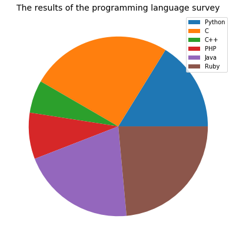

```python
plt.figure(figsize=(9, 7))
plt.pie(data)
plt.title('The results of the programming language survey', fontsize=14)
plt.legend(labels)
plt.show()
```

### Explode

The `explode` parameter in `pie charts` separates a slice from the main pie. To highlight some of the fractions, we need to pass a list of values to the explode parameter. The values determine how far we want to separate this category from the main pie.

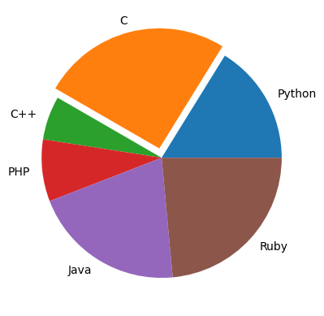

```python
import matplotlib.pyplot as plt

explode = [0.0, 0.08, 0.0, 0.0,0.0,0.0]
data=[33,52,12,17,42,48]

labels=['Python','C','C++','PHP','Java','Ruby']
plt.pie(data, explode=explode, labels=labels)
plt.show()
```

### Colors and shadows

To make our graph even more illustrative, we can pass a list of colors to the color parameter and add a shadow underneath by setting the `shadow` to `True`:

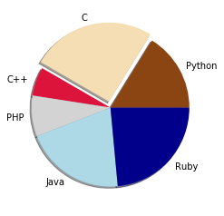

```python
colors = ['saddlebrown', 'wheat', 'crimson', 'lightgrey','lightblue','darkblue']
plt.pie(data,
        explode=explode,
        labels=labels,
        colors=colors,
        shadow=True)
plt.show()
```

### Display the value

The `autopct` parameter displays the percent value on the slices. If `autopct` is `%.2f`, then for each pie slice, the format string is `%.2f`, where `%`is a special character that tells when to type the value, `f` sets the result to be a floating-point type, and the `.2` sets a limit to only 2 digits after the point.

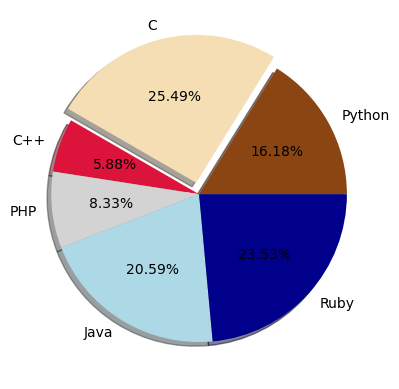

```python
import matplotlib.pyplot as plt
explode = [0.0, 0.08, 0.0, 0.0,0.0,0.0]
labels=['Python','C','C++','PHP','Java','Ruby']
data=[33,52,12,17,42,48]
colors = ['saddlebrown', 'wheat', 'crimson', 'lightgrey','lightblue','darkblue']
plt.pie(data,
        explode=explode,
        labels=labels,
        colors=colors,
        autopct='%.2f%%',    # here we also add the % sign
        shadow=True)
plt.show()
```

### Starting angle

By default, pie charts are plotted from the x-axis; slices are plotted counterclockwise:

The `startangle` parameter lets us define the angle where we want to initiate our pie (the default angle is 0). You can choose whether you want to plot the slices counterclockwise by changing the counterclock parameter; it is `True by` default.

Let's assume we want the slices to start at 90 degrees.

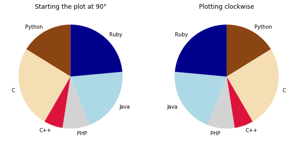

```python
fig, axes = plt.subplots(1, 2, figsize=(10, 6))
ax1, ax2 = axes

ax1.pie(data, labels=labels, colors=colors, startangle=90)
ax2.pie(data, labels=labels, colors=colors, startangle=90, counterclock=False)
ax1.set_title('Starting the plot at 90°')
ax2.set_title('Plotting clockwise')
plt.show()
```

# The doughnut chart

A doughnut chart is very similar to a pie chart. However, since a doughnut chart has an opening at the center, it makes slices look more like bars. Unfortunately, there is no specific method for plotting a doughnut chart in the matplotlib library. But we can use the `wedgeprops` parameter to define the width of the wedges.

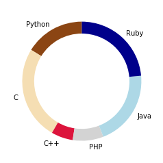

```python
plt.pie(data,
        labels=labels,
        colors=colors,
        startangle=90,
        wedgeprops={'width': 0.2})
plt.show()
```

The `wedgeprops` parameter also lets we change various pie slice features, such as `linewidth`, `edgecolor`, `alpha` (for transparency), and many others.

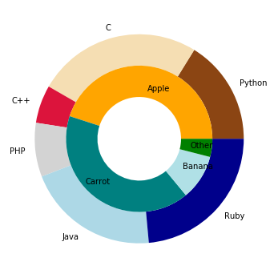

```python
fig, ax = plt.subplots(figsize=(8, 6))
width = 0.3

p_pie = ax.pie(data,radius=1,labels=labels, colors=colors,wedgeprops = {'width': width})

pets_data = [45, 41, 10, 4]
pets_labels = ['Apple', 'Carrot', 'Banana', 'Other']
pets_colors = ['orange', 'teal', 'powderblue', 'green']
pets_pie = ax.pie(pets_data,
                  radius=1-width,
                  labels=pets_labels,
                  labeldistance=0.7,
                  colors=pets_colors,
                  wedgeprops = {'width': width})

plt.show()
```

# The heatmap

A `heatmap` is a graph that extensively uses color for data visualization. The colors depend on several independent variables. There are two different kinds of heatmap: a `cluster heatmap` (a cell-matrix of different colors) and a `spatial heatmap` (it has no cells; the variable variation is considered continuous).

### Dealing with data

First, we need to prepare the data we want to plot. In this case, we've chosen the [Iris Species dataset](https://www.kaggle.com/uciml/iris). It includes three iris species with 50 samples each as well as some properties about each flower.

```python
import pandas as pd
df = pd.read_csv('./data/Iris.csv')
df.head()
```

|  | Id | SepalLengthCm | SepalWidthCm | PetalLengthCm | PetalWidthCm | Species |
| --- | --- | --- | --- | --- | --- | --- |
| 0 | 1 | 5.1 | 3.5 | 1.4 | 0.2 | Iris-setosa |
| 1 | 2 | 4.9 | 3.0 | 1.4 | 0.2 | Iris-setosa |
| 2 | 3 | 4.7 | 3.2 | 1.3 | 0.2 | Iris-setosa |
| 3 | 4 | 4.6 | 3.1 | 1.5 | 0.2 | Iris-setosa |
| 4 | 5 | 5.0 | 3.6 | 1.4 | 0.2 | Iris-setosa |

Heatmaps are popular as correlation plots. We'll see whether there's a correlation between the SepalLength, SepalWidth,PetalLength parameters, and PetalWidth.

```python
df = df[['SepalLengthCm', 'SepalWidthCm', 'PetalLengthCm', 'PetalWidthCm']]
df.corr()
```

|  | SepalLengthCm | SepalWidthCm | PetalLengthCm | PetalWidthCm |
| --- | --- | --- | --- | --- |
| SepalLengthCm | 1.000000 | -0.109369 | 0.871754 | 0.817954 |
| SepalWidthCm | -0.109369 | 1.000000 | -0.420516 | -0.356544 |
| PetalLengthCm | 0.871754 | -0.420516 | 1.000000 | 0.962757 |
| PetalWidthCm | 0.817954 | -0.356544 | 0.962757 | 1.000000 |

### A Simple heatmap

There are several functions in `matplotlib` that you can use to create a `heatmap`. we'll focus on `plt.imshow()`. The only argument it requires is `X` – a dataset to a plot:

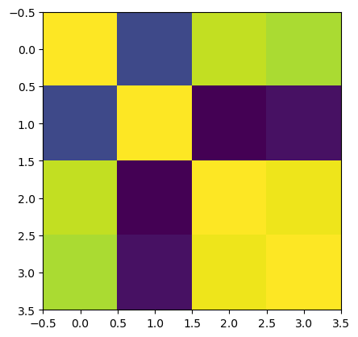

```python
plt.imshow(df.corr())
```

A dataset can be either a positional or a keyword argument, so you can type `plt.imshow(X=df.corr())` or `plt.imshow(df.corr())` — the result would be the same.

There iss another important argument this function can take — `interpolation`. It takes a `str` that specifies an interpolation we want on our plot. The default value is `None`.

### Changing color and size

Let's add a `color bar`, a scale that specifies the meaning of colors in our plot. All we need for that is the `plt.colorbar()` function without any arguments.By default, a color bar is a vertical line on the right side of the plot. If you want to put it beneath the heatmap, you can use the optional argument `orientation` and set it as `orientation='horizontal'`.

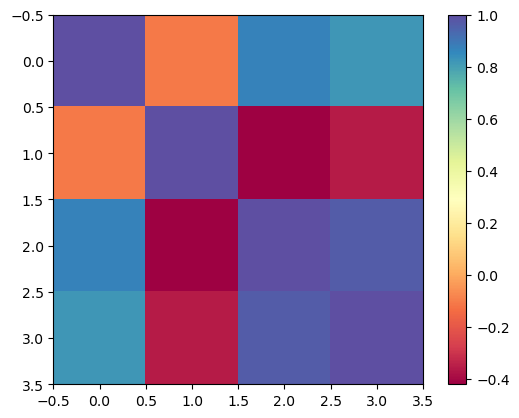

```python
plt.imshow(df.corr(), cmap="Spectral")
plt.colorbar()
plt.show()
```

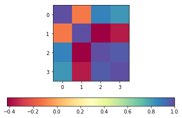

```python
plt.imshow(df.corr(), cmap="Spectral")
plt.colorbar(orientation='horizontal')
plt.show()
```

We can also change the size of plot just need the `plt.gcf().set_size_inches()` function it takes two integers as its arguments.

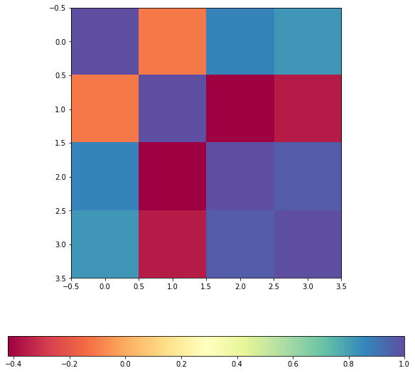

```python
plt.imshow(df.corr(), cmap="Spectral")
plt.colorbar(orientation='horizontal')
plt.gcf().set_size_inches(10, 10)
plt.show()
```

### Adding labels

We can also add labels to our plot to make it more comprehensive. To add them to the plot, use functions `plt.xticks()` and `plt.yticks()` for `X`- and `Y`-axes.

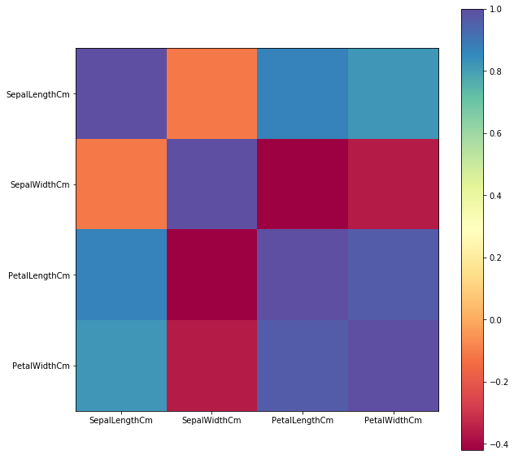

```python
plt.imshow(df.corr(), cmap="Spectral")
plt.colorbar()
plt.gcf().set_size_inches(10, 10)
plt.xticks(range(len(df.corr().columns)), df.corr().columns)
plt.yticks(range(len(df.corr().columns)), df.corr().columns)
plt.show()
```

Now let's add values to cells and add a title to our plot.

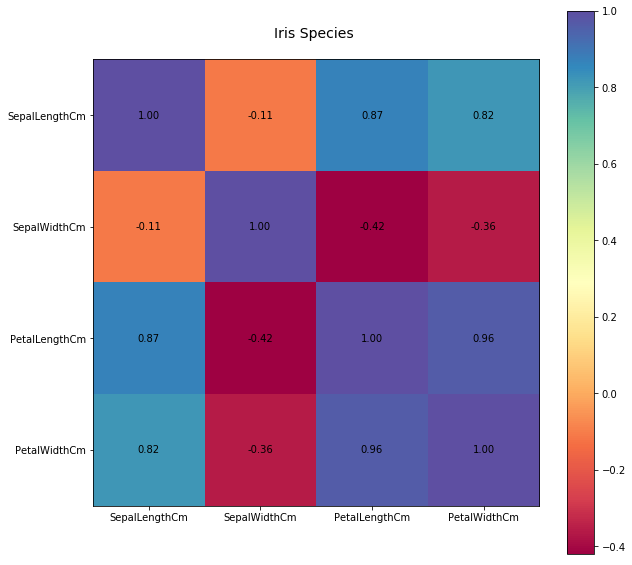

```python
plt.imshow(df.corr(), cmap="Spectral")
plt.colorbar()
plt.gcf().set_size_inches(10, 10)
plt.xticks(range(len(df.corr().columns)), df.corr().columns)
plt.yticks(range(len(df.corr().columns)), df.corr().columns)
labels = df.corr().values
for a in range(labels.shape[0]):
    for b in range(labels.shape[1]):
        plt.text(a, b, '{:.2f}'.format(labels[b, a]), ha='center', va='center', color='black')
plt.title('Iris Species \n', fontsize=14)
plt.show()
```

# The bar chart

A bar chart is a diagram where variables are represented as rectangular bars the taller or longer the bar, the higher value it represents. Usually, one axis of a bar chart represents a category, and the other is its value. A bar chart is used to compare discrete data, such as occurrences or proportions.

### Creating a bar chart

To create a bar chart with `matplotlib`, simply need to call the `bar()` function. The syntax for this method is as follows:

`plt.bar(x, height, width, bottom, align)`

where:

`x` is a category

`height` is the corresponding value.

`width` is how wide you want your bars(default value is `0.8`).

`bottom` is the base of the y-coordinate; in other words, it is the point where your bars start. The (default is `0`)

`align` is where you want to place your category names. By default, they are positioned at the bar center

Let's create our first simple bar graph. Suppose you want to compare the box office of the movies released in 2020 in the India.

[figure not shown]

```python
import matplot.pyplot as plt
films = ['Tanhaji', 'Baaghi3', 'LoveAajKal', 'JawaaniJaaneman',
         'StreetDancer3D']
box_office = [367.65, 137.05, 44.77, 52.63, 97]
plt.bar(films, box_office)
plt.show()
```

### Labels

Let's make chart more illustrative adding labels and title.

[figure not shown]

```python
plt.bar(films, box_office)

plt.ylabel('Box Office (crore . ₹)')  # labling y-axis
plt.xlabel('Film title')           # labling x-axis
plt.title('Box office of 5 different films of 2020 in the India')
plt.show()
```

### Gridlines

Another way to make chart more representative is adding gridlines. To add gridline call the `grid()` method and pass it as the parameters for `color`, `linestyle`, `width`, and `axis`. To make gridlines transparent need to tweak the alpha parameter. It can range from `0.0` to `1.0`.

[figure not shown]

```python
plt.bar(films, box_office)

# add grid lines
plt.grid(color='green', linestyle=':', linewidth=1.0, axis='y', alpha=0.5)

plt.ylabel('Box Office (crore . ₹)')  # labling y-axis
plt.xlabel('Film title')           # labling x-axis
plt.title('Box office of 5 different films of 2020 in the India')

plt.show()
```

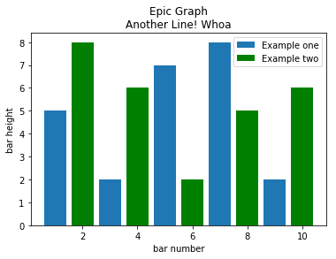

```python
plt.bar([1,3,5,7,9],[5,2,7,8,2], label="Example one")
plt.bar([2,4,6,8,10],[8,6,2,5,6], label="Example two", color='g')
plt.legend()
plt.xlabel('bar number')
plt.ylabel('bar height')

plt.title('Epic Graph\nAnother Line! Whoa')

plt.show()
```

## Horizontal bar chart

A bar chart can be display horizontally instead of vertically, just need to call the `barh()` function. But don't forget to switch the axes labels!

[figure not shown]

```python
import matplotlib.pyplot as plt
# plotting the chart horizontally
plt.barh(films, box_office)

plt.xlabel('Box Office (crore . ₹)')
plt.ylabel('Film title')
plt.title('Box office of 5 different films of 2020 in the India')

plt.show()
```

## Grouped bar plot

Plotting multiple bars next to each other can come in handy when we need to compare two or more data series that share categories.

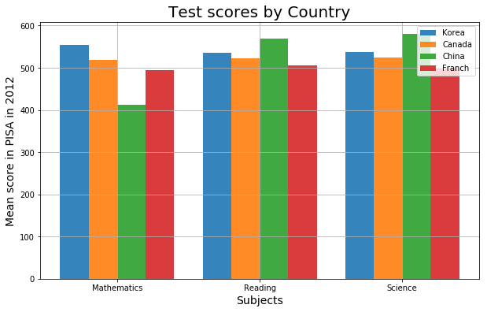

```python
korea_scores=(554,536,538)
canada_scores=(518,523,525)
china_scores=(413,570,580)
franch_scores=(495,505,499)

index=np.arange(3)
bar_width=.2

plt.figure(figsize=(10, 6))
k1=plt.bar(index,korea_scores,bar_width,alpha=.9,label="Korea")
c1=plt.bar(index+bar_width,canada_scores,bar_width,alpha=.9,label="Canada")
ch1=plt.bar(index+bar_width*2,china_scores,bar_width,alpha=.9,label="China")
f1=plt.bar(index+bar_width*3,franch_scores,bar_width,alpha=.9,label="Franch")

plt.xticks(index+.6/2,('Mathematics','Reading','Science'))
plt.ylabel('Mean score in PISA in 2012',fontsize=14)
plt.xlabel('Subjects',fontsize=14)
plt.title('Test scores by Country',fontsize=20)
plt.grid(True)
plt.legend()
plt.show()
```

## Stacked bar plot

A stacked bar chart is a type of graph that displays multiple data points on top of each other. In a stacked bar chart, each bar represents a single category that contains smaller categories. Use it to demonstrate how parts relate to the total amount.

In stacked bar plots need to provide the additional bottom parameter that indicates where the bar should start.

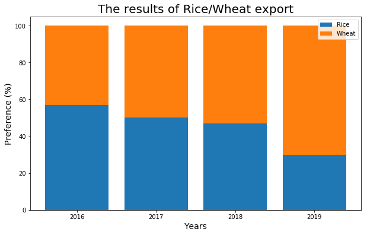

```python
years = ['2016', '2017', '2018', '2019']
rice = [57, 50, 47, 30]
wheat = [43, 50, 53, 70]

plt.figure(figsize=(10, 6))

plt.bar(years, rice, label='Rice')
plt.bar(years, wheat, bottom=rice, label='Wheat')

plt.xlabel('Years', fontsize=14)
plt.ylabel('Preference (%)', fontsize=14)
plt.title('The results of Rice/Wheat export', fontsize=20)
plt.legend()
plt.show()
```

If you need to stack three or more categories, provide a sum of the previous category values to the bottom parameter.

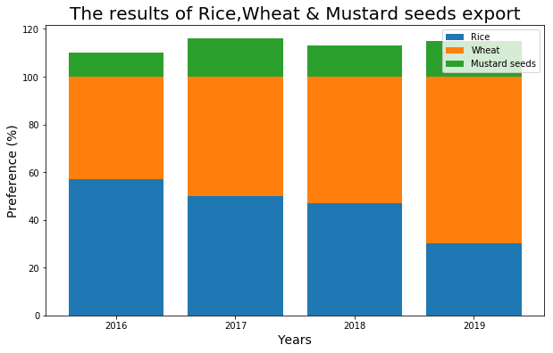

```python
years = ['2016', '2017', '2018', '2019']
rice =  np.array([57, 50, 47, 30])
wheat =  np.array([43, 50, 53, 70])
mustard =  np.array([10, 16, 13, 15])

plt.figure(figsize=(10, 6))

plt.bar(years, rice, label='Rice')
plt.bar(years, wheat, bottom=rice, label='Wheat')
plt.bar(years, mustard, bottom=rice+wheat, label='Mustard seeds')

plt.xlabel('Years', fontsize=14)
plt.ylabel('Preference (%)', fontsize=14)
plt.title('The results of Rice,Wheat & Mustard seeds export', fontsize=20)
plt.legend()
plt.show()
```

# The Histogram

A `histogram` is a graphical display of data that organizes groups of data points into ranges. These ranges are represented by bars. It resembles a bar chart, but it's not quite the same. The key difference is that you use a bar chart for categorical data representation, while a histogram displays only numerical data. Examples of this might be age groups, or scores on a test. Rather than showing every single age a group might be, maybe you just show people from 20-25, 25-30... and so on.

### Creating a simple histogram

Let's say you've decided to plot the height of your classmate. Now, let's create a very simple histogram with only 10 values:

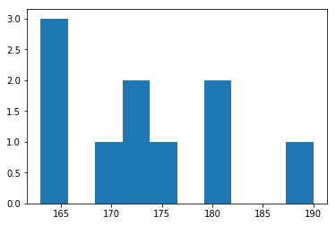

```python
import matplotlib.pyplot as plt
data = [163, 163, 164, 170, 180, 172, 173, 190,175,180]
plt.hist(data)
```

To make it clearer, we need to specify the values for `plt.title()`, `plt.xlabel()`, and `plt.ylabel()`. The color can be change by using the color argument and adding a border between adjacent bars with `edgecolor`.

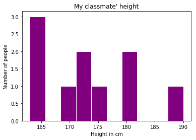

```python
plt.hist(data, color="purple", edgecolor="white")
plt.title("My classmate' height")
plt.ylabel("Number of people")
plt.xlabel("Height in cm")
plt.show()
```

### Changing bins

Let's say we want to divide our data values into 3 groups: from 160 to 170 cm, from 170 to 180, and from 180 to 190. To do that, we need to pass a list of these values to the bins argument:

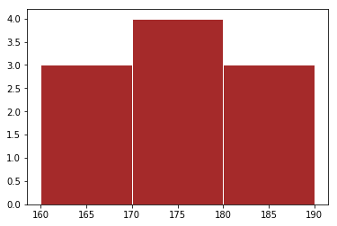

```python
bins = [160, 170, 180, 190]
plt.hist(data, bins=bins, color="brown", edgecolor='white')
```

The `bins` argument can take not only a `list` but also an `int`. A `list` defines bin edges. An `int` defines the number of equal-width bins. So, if we want to have four bins in our histogram, we simply write `bins=4`. There's also a third option – use a `str` as bins value. It has to be a name of one of the binning functions supported by `numpy`, such as 'rice', 'scott', 'sqrt', and so on

### Cutting off data

Sometimes, you just don't need all the data that's in there. All you need to do is to pass a tuple to the range argument that specifies the start and end values. Assume that we only want to see people from 180 to 190 cm in our histogram:

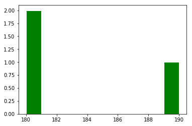

```python
plt.hist(data, color="green", edgecolor='white', range=(180, 190))
```

### Plotting multiple datasets

To plot multiple datasets together to compare them you need to pass a list of datasets to `plt.hist()` and, preferably, add `plt.legend()` to make your plot easier to interpret.

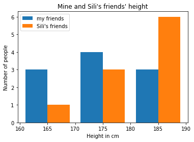

```python
my_data = [163, 163, 164, 170, 170, 172, 173, 190,190,180]
sili_data = [161, 172, 174, 175, 181, 183, 186, 190,180,185]
bins = [160, 170, 180, 190]
names = ["my friends", "Sili's friends"]

plt.hist([my_data, sili_data], bins=bins, label=names)
plt.title("Mine and Sili's friends' height")
plt.ylabel("Number of people")
plt.xlabel("Height in cm")

plt.legend()
plt.show()
```

By default bars are placed side-by-side.The alternative way is to stack the values on top of each other. You can do that by setting the `stacked` argument to `True`. We also add `edgecolor` for better readability:

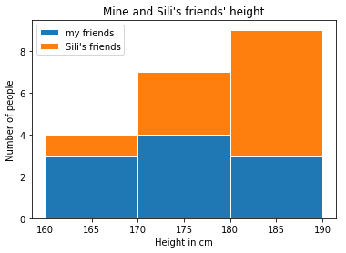

```python
plt.hist([my_data, sili_data], bins=bins, label=names, stacked=True, edgecolor='white')
plt.title("Mine and Sili's friends' height")
plt.ylabel("Number of people")
plt.xlabel("Height in cm")

plt.legend()
plt.show()
```

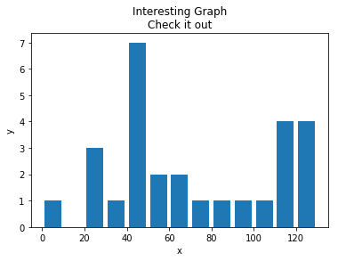

```python
population_ages = [22,55,62,45,21,22,34,42,42,4,99,102,110,120,121,122,130,111,115,112,80,75,65,54,44,43,42,48]

bins = [0,10,20,30,40,50,60,70,80,90,100,110,120,130]

plt.hist(population_ages, bins, histtype='bar', rwidth=0.8)

plt.xlabel('x')
plt.ylabel('y')
plt.title('Interesting Graph\nCheck it out')
plt.show()
```

### Scatter Plots

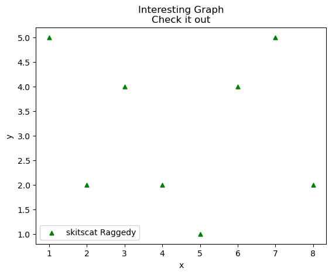

```python
import matplotlib.pyplot as plt
x = [1,2,3,4,5,6,7,8]
y = [5,2,4,2,1,4,5,2]

plt.scatter(x,y, label='skitscat Raggedy', color='g', s=25, marker='^')

plt.xlabel('x')
plt.ylabel('y')
plt.title('Interesting Graph\nCheck it out')
plt.legend()
plt.show()
```

### Stack Plots

A stack plot is basically like a pie-chart, only over time.

Let's consider a situation where we have 24 hours in a day, and we'd like to see how we're spending our time. We'll divide our activities into: Sleeping, eating, working, and playing.

We're going to assume that we're tracking this over the course of 5 days, so our starting data will look like:

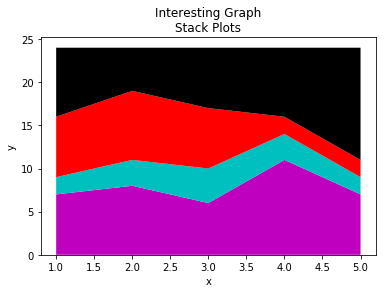

```python
days = [1,2,3,4,5]

sleeping = [7,8,6,11,7]
eating =   [2,3,4,3,2]
working =  [7,8,7,2,2]
playing =  [8,5,7,8,13]
plt.stackplot(days, sleeping,eating,working,playing, colors=['m','c','r','k'])

plt.xlabel('x')
plt.ylabel('y')
plt.title('Interesting Graph\nStack Plots')
plt.show()
```

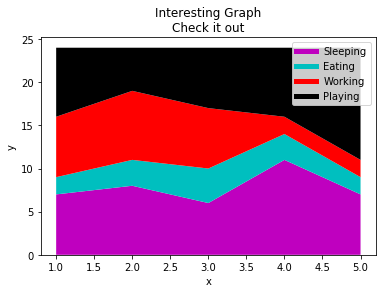

```python
days = [1,2,3,4,5]

sleeping = [7,8,6,11,7]
eating =   [2,3,4,3,2]
working =  [7,8,7,2,2]
playing =  [8,5,7,8,13]


plt.plot([],[],color='m', label='Sleeping', linewidth=5)
plt.plot([],[],color='c', label='Eating', linewidth=5)
plt.plot([],[],color='r', label='Working', linewidth=5)
plt.plot([],[],color='k', label='Playing', linewidth=5)

plt.stackplot(days, sleeping,eating,working,playing, colors=['m','c','r','k'])

plt.xlabel('x')
plt.ylabel('y')
plt.title('Interesting Graph\nCheck it out')
plt.legend()
plt.show()
```

### 3D graphs

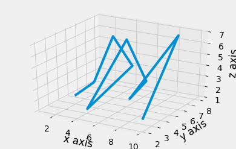

```python
from mpl_toolkits.mplot3d import axes3d
import matplotlib.pyplot as plt
from matplotlib import style

style.use('fivethirtyeight')

fig = plt.figure()
ax1 = fig.add_subplot(111, projection='3d')

x = [1,2,3,4,5,6,7,8,9,10]
y = [5,6,7,8,2,5,6,3,7,2]
z = [1,2,6,3,2,7,3,3,7,2]

ax1.plot(x,y,z)

ax1.set_xlabel('x axis')
ax1.set_ylabel('y axis')
ax1.set_zlabel('z axis')

plt.show()
```

### 3D Scatter Plot

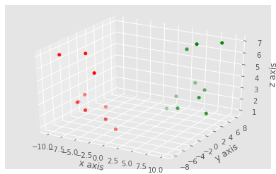

```python
from mpl_toolkits.mplot3d import axes3d
import matplotlib.pyplot as plt
from matplotlib import style

style.use('ggplot')

fig = plt.figure()
ax1 = fig.add_subplot(111, projection='3d')

x = [1,2,3,4,5,6,7,8,9,10]
y = [5,6,7,8,2,5,6,3,7,2]
z = [1,2,6,3,2,7,3,3,7,2]

x2 = [-1,-2,-3,-4,-5,-6,-7,-8,-9,-10]
y2 = [-5,-6,-7,-8,-2,-5,-6,-3,-7,-2]
z2 = [1,2,6,3,2,7,3,3,7,2]

ax1.scatter(x, y, z, c='g', marker='o')
ax1.scatter(x2, y2, z2, c ='r', marker='o')

ax1.set_xlabel('x axis')
ax1.set_ylabel('y axis')
ax1.set_zlabel('z axis')

plt.show()
```

### 3D Bar Chart

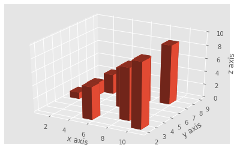

```python
from mpl_toolkits.mplot3d import axes3d
import matplotlib.pyplot as plt
import numpy as np
from matplotlib import style
style.use('ggplot')

fig = plt.figure()
ax1 = fig.add_subplot(111, projection='3d')

x3 = [1,2,3,4,5,6,7,8,9,10]
y3 = [5,6,7,8,2,5,6,3,7,2]
z3 = np.zeros(10)

dx = np.ones(10)
dy = np.ones(10)
dz = [1,2,3,4,5,6,7,8,9,10]

ax1.bar3d(x3, y3, z3, dx, dy, dz)


ax1.set_xlabel('x axis')
ax1.set_ylabel('y axis')
ax1.set_zlabel('z axis')

plt.show()
```

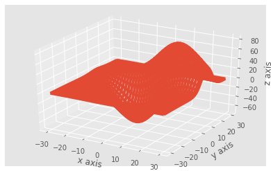

```python
from mpl_toolkits.mplot3d import axes3d
import matplotlib.pyplot as plt
import numpy as np
from matplotlib import style
style.use('ggplot')

fig = plt.figure()
ax1 = fig.add_subplot(111, projection='3d')

x, y, z = axes3d.get_test_data()

ax1.plot_wireframe(x,y,z, rstride = 3, cstride = 3)

ax1.set_xlabel('x axis')
ax1.set_ylabel('y axis')
ax1.set_zlabel('z axis')

plt.show()
```

## Plotting Images

### Importing image data into Numpy arrays

Natively, Matplotlib only supports PNG images. [Pillow](https://pillow.readthedocs.io/en/latest/) library is very usefull for loading different kind of image data.

```python
img = mpimg.imread('./data/test_image_png_1051.png')
print(img)
```

[output not shown]

### Plotting numpy arrays as images

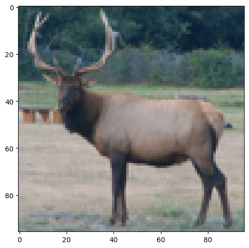

```python
plt.figure(figsize=(10,6))
imgplot = plt.imshow(img)
```

### Applying pseudocolor schemes to image plots

Pseudocolor is a useful tool for enhancing contrast and visualizing data more easily. This is especially useful when making presentations of data using projectors - their contrast is typically quite poor.

Pseudocolor is only relevant to single-channel, grayscale, luminosity images. We currently have an RGB image. Since R, G, and B are all similar, we can just pick one channel of our data:

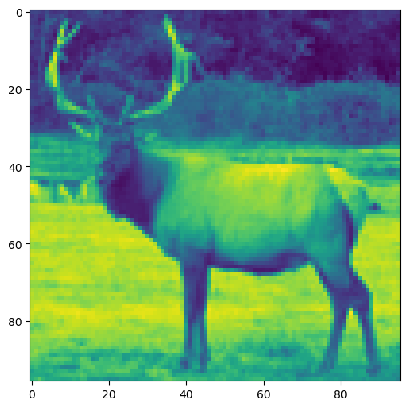

```python
plt.figure(figsize=(10,6))
lum_img = img[:, :, 0]
plt.imshow(lum_img)
```

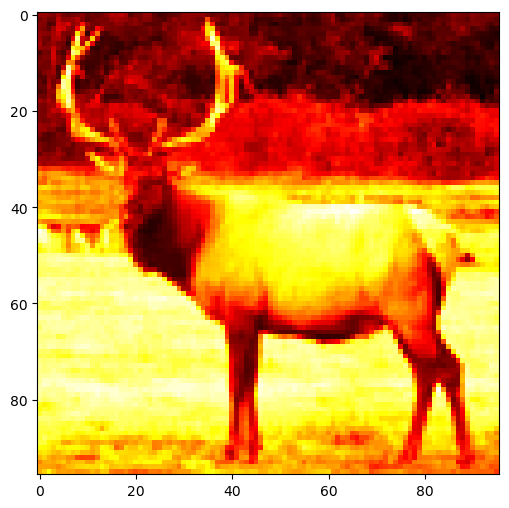

```python
plt.figure(figsize=(10,6))
plt.imshow(lum_img, cmap="hot")
```

Change colormaps on existing plot objects using the set_cmap() method:

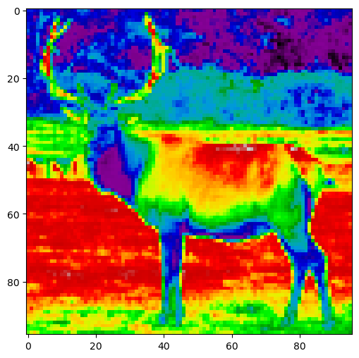

```python
plt.figure(figsize=(10,6))
imgplot = plt.imshow(lum_img)
imgplot.set_cmap('nipy_spectral')
```

### Color scale

It's helpful to have an idea of what value a color represents. We can do that by adding color bars.

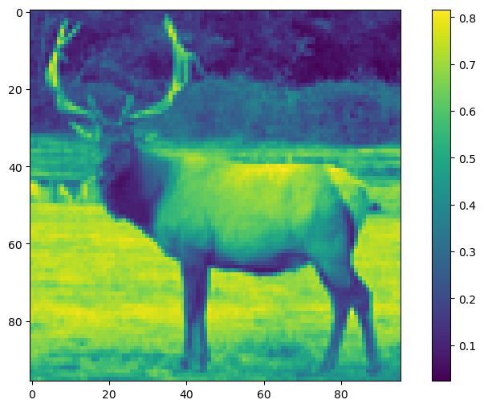

```python
plt.figure(figsize=(10,6))
imgplot = plt.imshow(lum_img)
plt.colorbar()
```

### Examining a specific data range

To enhance the contrast in image, or expand the contrast in a particular region while sacrificing the detail in colors that don't vary much, or don't matter. A good tool to find interesting regions is the histogram. To create a histogram of image data, we use the `hist()` function.

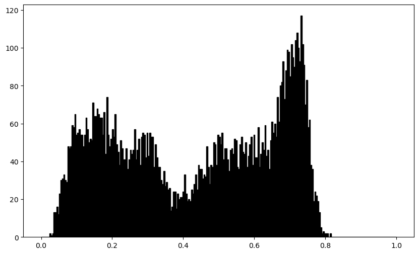

```python
plt.figure(figsize=(10,6))
plt.hist(lum_img.ravel(), bins=256, range=(0.0, 1.0), fc='k', ec='k')
```

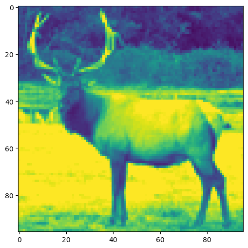

```python
plt.figure(figsize=(10,6))
imgplot = plt.imshow(lum_img, clim=(0.0, 0.7))
```

Specify the clim using the returned object

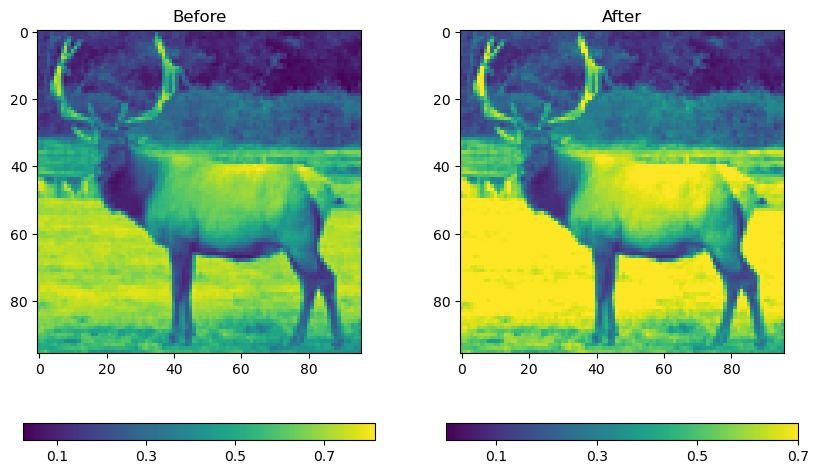

```python
fig = plt.figure(figsize=(10,6))
a = fig.add_subplot(1, 2, 1)
imgplot = plt.imshow(lum_img)
a.set_title('Before')
plt.colorbar(ticks=[0.1, 0.3, 0.5, 0.7], orientation='horizontal')
a = fig.add_subplot(1, 2, 2)
imgplot = plt.imshow(lum_img)
imgplot.set_clim(0.0, 0.7)
a.set_title('After')
plt.colorbar(ticks=[0.1, 0.3, 0.5, 0.7], orientation='horizontal')
```

### Array Interpolation schemes

Interpolation calculates what the color or value of a pixel "should" be, according to different mathematical schemes. One common place that this happens is when you resize an image. The number of pixels change, but you want the same information. Since pixels are discrete, there's missing space. Interpolation is how you fill that space. This is why your images sometimes come out looking pixelated when you blow them up. The effect is more pronounced when the difference between the original image and the expanded image is greater. Let's take our image and shrink it. We're effectively discarding pixels, only keeping a select few. Now when we plot it, that data gets blown up to the size on your screen. The old pixels aren't there anymore, and the computer has to draw in pixels to fill that space.

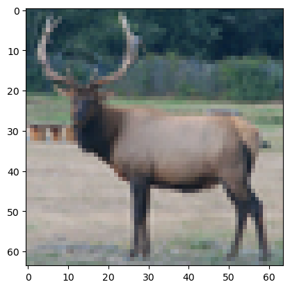

```python
from PIL import Image

img = Image.open('./data/test_image_png_1051.png')
img.thumbnail((64, 64), Image.ANTIALIAS)  # resizes image in-place
imgplot = plt.imshow(img)
```

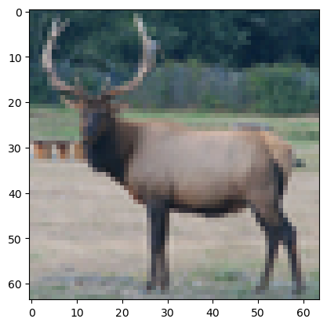

```python
imgplot = plt.imshow(img, interpolation="nearest")
```

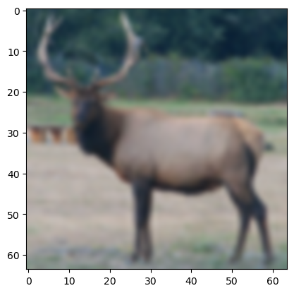

```python
imgplot = plt.imshow(img, interpolation="bicubic")
```